# Topic Models

*Patrick O. Perry, NYU Stern School of Business*

Most of the code here is taken from Chapter 10.3 of Taylor Arnold and Lauren Tilton's book, [Humanities Data in R](http://humanitiesdata.org/).

## Preliminaries

### Computing environment

We will use the following R packages.

```
library("mallet")
library("coreNLP")
```

To ensure consistent runs, we set the seed before performing any analysis.

```
set.seed(0)
```

### Data

Arnold and Tilton have provided tagged versions of the wikipedia pages for 179 philosophers. The data is available on their webpage (humanitiesDataInR.zip).

```
wikiFiles <- dir("data/ch10/wiki_annotations", full.names=TRUE)
wikiNames <- gsub("\\.Rds", "", basename(wikiFiles))
```

## Data preprocessing

### Order by year

The pre-processed corpus includes a `Timex` annotation for times. The following code pulls out the first year mentioned in each article; this is the philosopher's birth year.

```
dateSet <- rep(0, length(wikiFiles))
for (j in seq_along(wikiFiles)) {
    anno <- readRDS(wikiFiles[j])
    tx <- getToken(anno)$Timex
    tx <- substr(tx[!is.na(tx)], 1, 4)
    suppressWarnings({
        tx <- as.numeric(tx)
    })
    tx <- tx[!is.na(tx)]
    dateSet[j] <- tx[1]
}
```

Next, we order the documents by year

```
wikiFiles <- wikiFiles[order(dateSet)]
wikiNames <- wikiNames[order(dateSet)]
```

### Feature selection

Rather than fitting the topic model to the entire text, we fit the model to just the lemmas of the non-proper nouns. The following code segment filters the text using the POS-tagged and lemmatized corpus. For each document, we build a long text string containing all of the selected words, separated by spaces.

```
bagOfWords <- rep("", length(wikiFiles))
for (j in seq_along(wikiFiles)) {
    anno <- readRDS(wikiFiles[j])
    token <- getToken(anno)
    theseLemma <- token$lemma[token$POS %in% c("NNS", "NN")]
    bagOfWords[j] <- paste(theseLemma, collapse=" ")
}
```

To filter out stopwords, we need to store the words in a file. Since we already have used POS tags to filter out stop words, we only need to worry about initials that may have been mistaken for non-proper nouns by the tagger.

```
tf <- tempfile()
writeLines(c(letters, LETTERS), tf)
```

## Fitting

Here is code to train the topic model:

```
instance <- mallet.import(id.array=wikiNames, text.array=bagOfWords,
                          stoplist.file=tf)
tm <- MalletLDA(num.topics=9)
tm$loadDocuments(instance)
tm$setAlphaOptimization(20, 50)
tm$train(200)
tm$maximize(10)
```

These options specify how often to optimize the hyper-parameters (optimize alpha every 20 iterations after performing 50 burn-in iterations), how many training iterations to perform (200), and how iterations to use to determine the topics of each token (10). The values used here are the defaults suggested by the `mallet` package. Increasing these values may result in more consistent runs of the procedure.

After fitting the model we can now pull out the topics, the words, and the vocabulary:

```
topics <- mallet.doc.topics(tm, smoothed=TRUE, normalized=TRUE)
words <- mallet.topic.words(tm, smoothed=TRUE, normalized=TRUE)
vocab <- tm$getVocabulary()
```

Here are the dimensions of these objects:

```
dim(topics)
```

```
[1] 179   9
```

```
dim(words)
```

```
[1]     9 12123
```

```
length(vocab)
```

```
[1] 12123
```

## Results

Here are the top 5 words in each of the 9 topics:

```
t(apply(words, 1, function(v) vocab[order(v, decreasing=TRUE)[1:5]]))
```

```
      [,1]       [,2]          [,3]         [,4]          [,5]
 [1,] "man"      "faith"       "death"      "religion"    "view"
 [2,] "theory"   "society"     "view"       "development" "child"
 [3,] "theory"   "mathematics" "logic"      "set"         "science"
 [4,] "people"   "movement"    "party"      "war"         "leader"
 [5,] "language" "book"        "culture"    "field"       "relationship"
 [6,] "work"     "time"        "writer"     "poet"        "poem"
 [7,] "year"     "family"      "father"     "life"        "school"
 [8,] "law"      "state"       "government" "society"     "theory"
 [9,] "work"     "philosophy"  "idea"       "world"       "life"
```

The output of the topic model is sensitive to the random initialization. You will likely get different results every time you run this code. I do not know if it's possible to ensure consistent output from `mallet`. If you want your analysis to be reproducible, you should save the topic model output using a command like `saveRDS(list(topics=topics, words=words, vocab=vocab), "tm.rds")`.

For the remainder of this analysis, we will use the results from Arnold and Tilton's analysis:

```
tm <- readRDS("data/ch10/tm.Rds")
topics <- tm$topics
words <- tm$words
vocab <- tm$vocab
t(apply(words, 1, function(v) vocab[order(v, decreasing=TRUE)[1:5]]))
```

```
      [,1]         [,2]          [,3]       [,4]       [,5]
 [1,] "government" "time"        "man"      "nation"   "law"
 [2,] "year"       "life"        "time"     "death"    "family"
 [3,] "society"    "state"       "power"    "idea"     "class"
 [4,] "world"      "life"        "man"      "idea"     "self"
 [5,] "work"       "philosophy"  "book"     "theory"   "philosopher"
 [6,] "theory"     "mathematics" "logic"    "set"      "number"
 [7,] "culture"    "poem"        "poet"     "critic"   "writer"
 [8,] "man"        "race"        "time"     "religion" "life"
 [9,] "object"     "meaning"     "language" "word"     "world"
```

Commonly, people assign labels to the topics, based on the top 5 words.

```
topicNames <- c("politics", "biography", "social-science", "existentialism",
                "philosophy", "logic", "poetry", "culture", "language")
```

The next code segment shows the words with the highest activations for the topics:

```
index <- order(apply(words, 2, max), decreasing=TRUE)[1:50]
set <- unique(as.character(apply(words, 1, function(v)
                                 vocab[order(v, decreasing=TRUE)][1:5])))
index <- match(set, vocab)
mat <- round(t(words[,index]), 3)
mat <- mat / max(mat)

plot(0, 0, col="white", t="n", axes=FALSE, xlab="", ylab="",
     ylim=c(-1, nrow(mat)), xlim=c(-2,ncol(mat)))
for (i in seq_len(nrow(mat))) {
    lines(x=c(1,ncol(mat)), y=c(i,i))
}
for (i in seq_len(ncol(mat))) {
    lines(x=c(i,i), y=c(1,nrow(mat)))
}
points(col(mat), nrow(mat) - row(mat) + 1, pch=19,
       cex=mat*3, col=rainbow(ncol(mat), alpha=0.33)[col(mat)])
text(0.5, nrow(mat):1, vocab[index], adj=c(1,0.5), cex=0.7)
text(1:ncol(mat), -0.75, topicNames, adj=c(0.5,0), cex=0.7, srt=60)
```

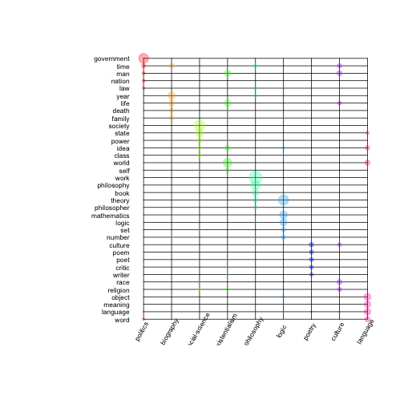

We can also plot the topic distributions of the documents in the corpus:

```
mat <- topics / max(topics)
plot(0, 0, col="white", t="n", axes=FALSE, xlab="", ylab="",
     ylim=c(-1, nrow(mat)), xlim=c(-2,ncol(mat)))
for (i in seq_len(nrow(mat))) {
    lines(x=c(1,ncol(mat)), y=c(i,i))
}
for (i in seq_len(ncol(mat))) {
    lines(x=c(i,i), y=c(1,nrow(mat)))
}
points(col(mat), nrow(mat) - row(mat) + 1, pch=19,
       cex=mat*3, col=rainbow(ncol(mat), alpha=0.33)[col(mat)])
text(0.5, nrow(mat):1, wikiNames, adj=c(1,0.5), cex=0.7)
text(1:ncol(mat), -0.75, topicNames, adj=c(0.5,0), cex=0.7, srt=60)
```

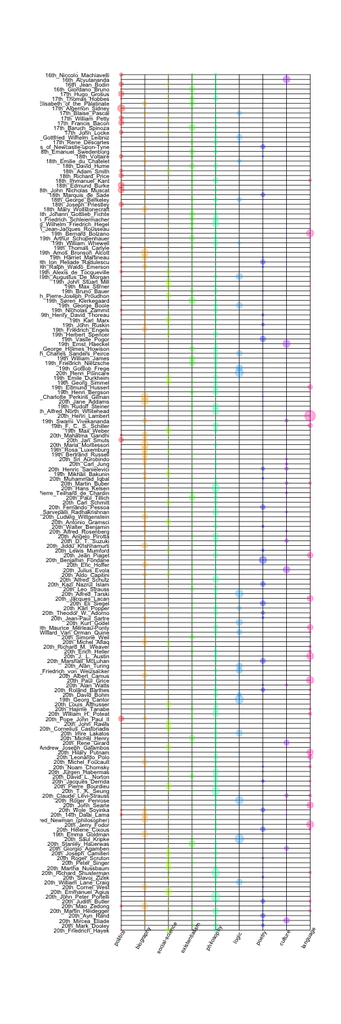

```
R version 3.2.3 (2015-12-10)
Platform: x86_64-apple-darwin13.4.0 (64-bit)
Running under: OS X 10.10.5 (Yosemite)

locale:
[1] en_US.UTF-8/en_US.UTF-8/en_US.UTF-8/C/en_US.UTF-8/en_US.UTF-8

attached base packages:
[1] methods   stats     graphics  grDevices utils     datasets  base

other attached packages:
[1] coreNLP_0.4-1      mallet_1.0         rJava_0.9-8        RColorBrewer_1.1-2 knitr_1.12.3

loaded via a namespace (and not attached):
 [1] magrittr_1.5     formatR_1.1      tools_3.2.3      codetools_0.2-14 stringi_1.0-1
 [6] plotrix_3.6-1    digest_0.6.8     stringr_1.0.0    XML_3.98-1.3     evaluate_0.8
```